# GARSIDE_Skills_Test_3

2025-11-29

# Load Packages

Before I do anything, I need to make sure that all of the packages I’m going to be using are loaded.

```r
library(tidyverse)
library(broom)
library(purrr)
```

# TASK I

To begin, I read-in the data set and looked at it so I could figure out what to clean. It looked like my best bet would be to separate the data set into three pieces (salary, comp, and count), fix the problem columns, then join them all back together. Even though the graph I replicated doesn’t include most of the columns I decided to keep/fix, I wanted to keep the data as close to the original set as possible. I was also struggling to figure out how to filter out the additional school tier VIIB, so I used Grok and got my code from what it suggested.

```r
faculty_df <- read.csv('FacultySalaries_1995.csv')
View(faculty_df)
str(faculty_df)
names(faculty_df)

keep = c("FedID","UnivName","State","Tier")

salary_df <- faculty_df %>%
  select(keep, AvgAssistProfSalary, AvgAssocProfSalary, AvgFullProfSalary) %>%
  filter(Tier %in% c("I", "IIA", "IIB")) %>%
  pivot_longer(
    cols = starts_with("Avg"),
    names_to = "Rank",
    values_to = "Salary") %>%
  mutate(
    Rank = case_when(
      Rank == "AvgAssistProfSalary" ~ "Assist",
      Rank == "AvgAssocProfSalary" ~ "Assoc",
      Rank == "AvgFullProfSalary" ~ "Full"),
    Rank = factor(Rank, levels = c("Assist", "Assoc", "Full")),
    Tier = factor(Tier, levels = c("I", "IIA", "IIB")))

comp_df <- faculty_df %>%
  select(keep, AvgAssistProfComp, AvgAssocProfComp, AvgFullProfComp) %>%
  filter(Tier %in% c("I", "IIA", "IIB")) %>%
  pivot_longer(
    cols = starts_with("Avg"),
    names_to = "Rank",
    values_to = "Comp") %>%
  mutate(
    Rank = case_when(
      Rank == "AvgAssistProfComp" ~ "Assist",
      Rank == "AvgAssocProfComp" ~ "Assoc",
      Rank == "AvgFullProfComp" ~ "Full"),
    Rank = factor(Rank, levels = c("Assist", "Assoc", "Full")),
    Tier = factor(Tier, levels = c("I", "IIA", "IIB")))

count_df <- faculty_df %>%
  select(keep, "NumFullProfs", "NumAssocProfs", "NumAssistProfs") %>%
  filter(Tier %in% c("I", "IIA", "IIB")) %>%
  pivot_longer(
    cols = starts_with("Num"),
    names_to = "Rank",
    values_to = "Count") %>%
  mutate(
    Rank = case_when(
      Rank == "NumAssistProfs" ~ "Assist",
      Rank == "NumAssocProfs" ~ "Assoc",
      Rank == "NumFullProfs" ~ "Full"),
    Rank = factor(Rank, levels = c("Assist", "Assoc", "Full")),
    Tier = factor(Tier, levels = c("I", "IIA", "IIB")))

money_df = full_join(salary_df,comp_df)
clean_df = full_join(money_df,count_df)
```

Now that my data is all nice and clean, it’s time to replicate the graph. I noticed that there were some NA values in the salary column, so I wanted to make sure those were filtered out before plotting. However, just doing filter(is.na) was not working, so I used Grok to look up the error I was getting and I got the first four lines of code from what it suggested.

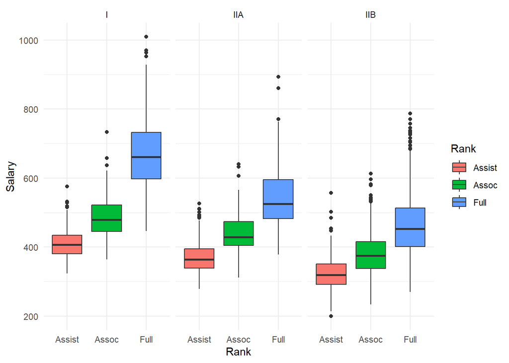

```r
clean_df %>%
  drop_na(Salary) %>%
  group_by(Tier, Rank) %>%
  filter(n() >= 2) %>%
  ungroup() %>%
  ggplot(aes(x = Rank,
             y = Salary,
             fill = Rank)) +
  geom_boxplot() +
  facet_wrap(~ Tier) +
  theme_minimal()
```

# TASK II

The next thing I need to do is build an ANOVA model that tests how salary is impacted by state, tier and rank. Since I couldn’t find anything on ANOVA in my notes or the class notes, I did some internet searching to figure out what I needed to do. Turns out, it’s like the linear modeling we did in class, so I just swapped glm() for aov().

```r
anova_mod = aov(data = clean_df,
                formula = Salary ~ State + Rank + Tier)
summary(anova_mod)
```

```
##               Df   Sum Sq Mean Sq F value Pr(>F)
## State         50  5667124  113342   31.17 <2e-16 ***
## Rank           2 16777001 8388501 2307.09 <2e-16 ***
## Tier           2  6821986 3410993  938.13 <2e-16 ***
## Residuals   3297 11987752    3636
## ---
## Signif. codes:  0 '***' 0.001 '**' 0.01 '*' 0.05 '.' 0.1 ' ' 1
## 128 observations deleted due to missingness
```

# TASK III

Now we are moving onto another data set. Like with the first one, I read it in and looked at it before cleaning. It looked like I basically just had to move the chemical names to a “ChemicalID” column and the values (Mass Spec Concentrations) to a “Concentrations” column. Unfortunately, the list given in the exam instructions uses - instead of . in the column names, so I had to get all of those swapped out (using Grok to help me).

```r
oils_df <- read.csv("Juniper_Oils.csv")
clean_oils_df = oils_df %>%
  rename_with(~ str_replace_all(., "\\.", "-")) %>%
  pivot_longer(c("alpha-pinene","para-cymene","alpha-terpineol","cedr-9-ene","alpha-cedrene","beta-cedrene","cis-thujopsene","alpha-himachalene","beta-chamigrene","cuparene","compound-1","alpha-chamigrene","widdrol","cedrol","beta-acorenol","alpha-acorenol","gamma-eudesmol","beta-eudesmol","alpha-eudesmol","cedr-8-en-13-ol","cedr-8-en-15-ol","compound-2","thujopsenal"),
               names_to = "ChemicalID",
               values_to = "Concentration")
```

# TASK IV

Now I have another figure to replicate. Luckily, this one is a little less complex.

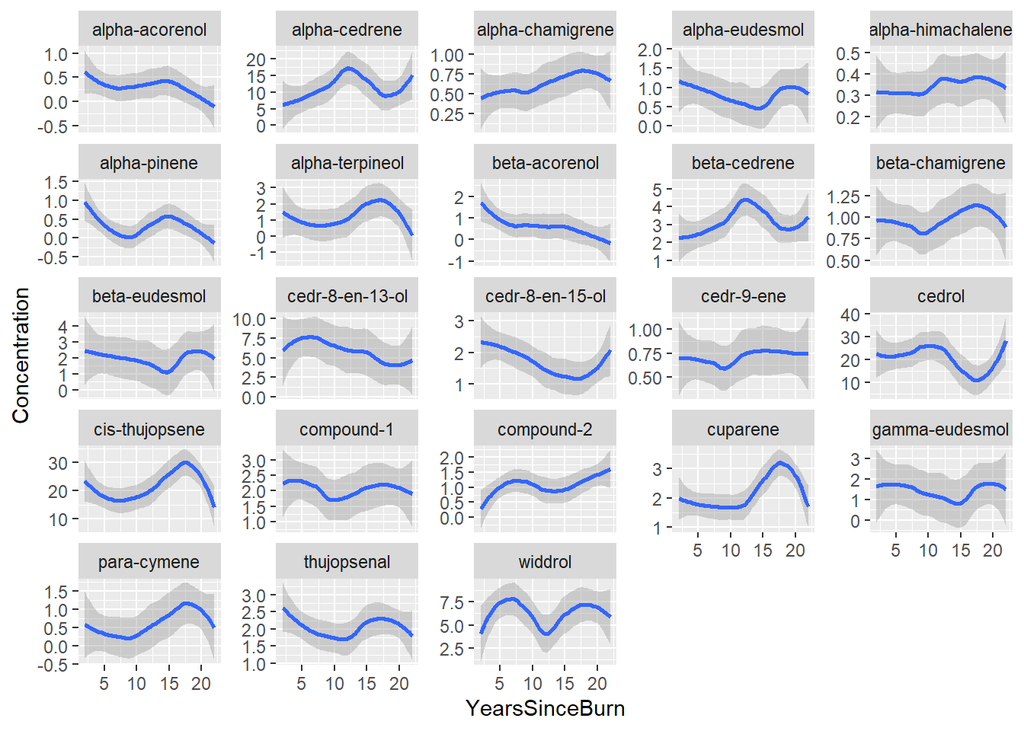

```r
clean_oils_df %>%
  ggplot(aes(x = YearsSinceBurn,
             y = Concentration)) +
  geom_smooth(method = 'loess') +
  facet_wrap(~ChemicalID, scales = 'free_y')
```

# TASK V

```r
significant_compounds = clean_oils_df %>%
  mutate(ChemicalID = as.character(ChemicalID)) %>%
  group_by(ChemicalID) %>%
  summarise(
    model = list(lm(Concentration ~ YearsSinceBurn)),
    tidy  = list(broom::tidy(model[[1]])),
    .groups = "drop") %>%
  unnest(tidy) %>%
  filter(p.value < 0.05) %>%
  mutate(term = if_else(term == "(Intercept)",
                        ChemicalID,
                        paste0(ChemicalID, ":YearsSinceBurn"))) %>%
  select(term, estimate, std.error, statistic, p.value) %>%
  arrange(p.value) %>%
  mutate(p.value = format(p.value, scientific = TRUE, digits = 2))
print(significant_compounds, n = 24)
```

```
## # A tibble: 24 × 5
##    term                         estimate std.error statistic p.value
##    <chr>                           <dbl>     <dbl>     <dbl> <chr>
##  1 thujopsenal                    2.16      0.261       8.29 1.8e-09
##  2 cedr-8-en-15-ol                2.26      0.299       7.56 1.3e-08
##  3 beta-chamigrene                0.913     0.141       6.47 2.8e-07
##  4 compound-1                     2.27      0.386       5.90 1.5e-06
##  5 cedrol                        23.1       4.17        5.54 4.1e-06
##  6 cis-thujopsene                17.8       3.28        5.43 5.7e-06
##  7 cedr-8-en-13-ol                8.17      1.52        5.36 7.1e-06
##  8 alpha-himachalene              0.306     0.0580      5.29 8.6e-06
##  9 widdrol                        6.36      1.23        5.19 1.2e-05
## 10 cedr-9-ene                     0.672     0.132       5.11 1.4e-05
## 11 beta-cedrene                   2.67      0.545       4.89 2.8e-05
## 12 cuparene                       1.53      0.333       4.60 6.3e-05
## 13 beta-acorenol                  1.38      0.309       4.46 9.6e-05
## 14 alpha-acorenol                 0.547     0.157       3.48 1.5e-03
## 15 alpha-chamigrene               0.450     0.130       3.45 1.6e-03
## 16 alpha-pinene                   0.596     0.189       3.15 3.5e-03
## 17 alpha-eudesmol                 0.908     0.292       3.12 3.9e-03
## 18 alpha-cedrene                  8.43      2.90        2.90 6.6e-03
## 19 beta-acorenol:YearsSinceBurn  -0.0655    0.0226     -2.90 6.6e-03
## 20 compound-2                     0.662     0.236       2.80 8.5e-03
## 21 beta-eudesmol                  1.98      0.749       2.64 1.3e-02
## 22 gamma-eudesmol                 1.53      0.623       2.46 2.0e-02
## 23 cuparene:YearsSinceBurn        0.0550    0.0244      2.26 3.1e-02
## 24 compound-2:YearsSinceBurn      0.0356    0.0173      2.06 4.7e-02
```